# BAN 614 Winter 2023 Final Project

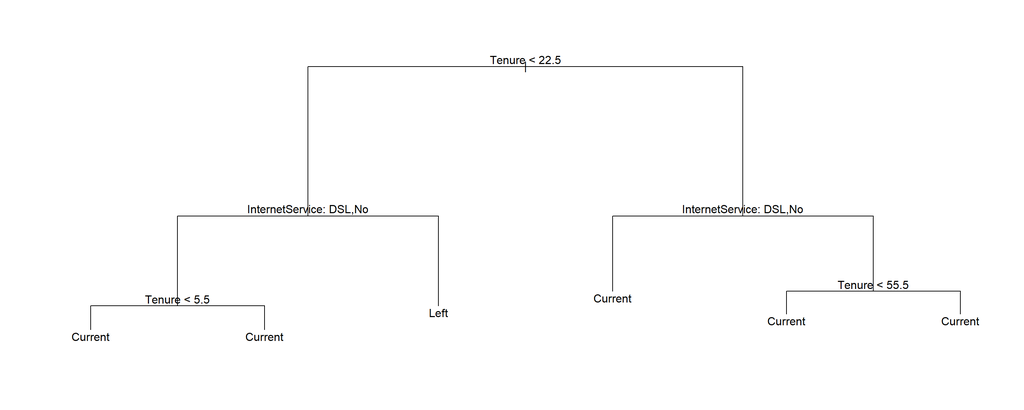

```
node), split, n, deviance, yval, (yprob)
      * denotes terminal node

 1) root 5599 6459.0 Current ( 0.73638 0.26362 )
   2) Tenure < 22.5 2414 3292.0 Current ( 0.57498 0.42502 )
     4) InternetService: DSL,No 1378 1593.0 Current ( 0.73512 0.26488 )
       8) Tenure < 5.5 636  848.8 Current ( 0.61321 0.38679 ) *
       9) Tenure > 5.5 742  653.4 Current ( 0.83962 0.16038 ) *
     5) InternetService: Fiber optic 1036 1356.0 Left ( 0.36197 0.63803 ) *
   3) Tenure > 22.5 3185 2594.0 Current ( 0.85871 0.14129 )
     6) InternetService: DSL,No 1757  686.6 Current ( 0.95105 0.04895 ) *
     7) InternetService: Fiber optic 1428 1621.0 Current ( 0.74510 0.25490 )
      14) Tenure < 55.5 804 1038.0 Current ( 0.65299 0.34701 ) *
      15) Tenure > 55.5 624  496.8 Current ( 0.86378 0.13622 ) *
```

```
List of 4
 $ size  : int [1:3] 6 3 1
 $ dev   : num [1:3] 1214 1214 1466
 $ k     : num [1:3] -Inf 0 143
 $ method: chr "misclass"
 - attr(*, "class")= chr [1:2] "prune" "tree.sequence"
```

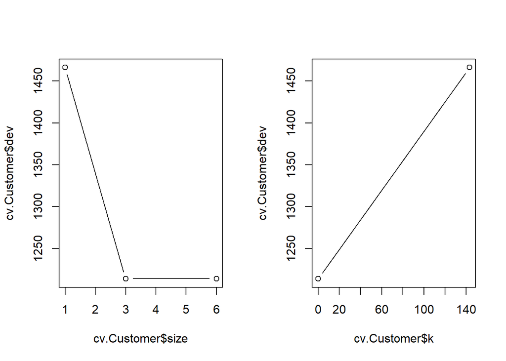

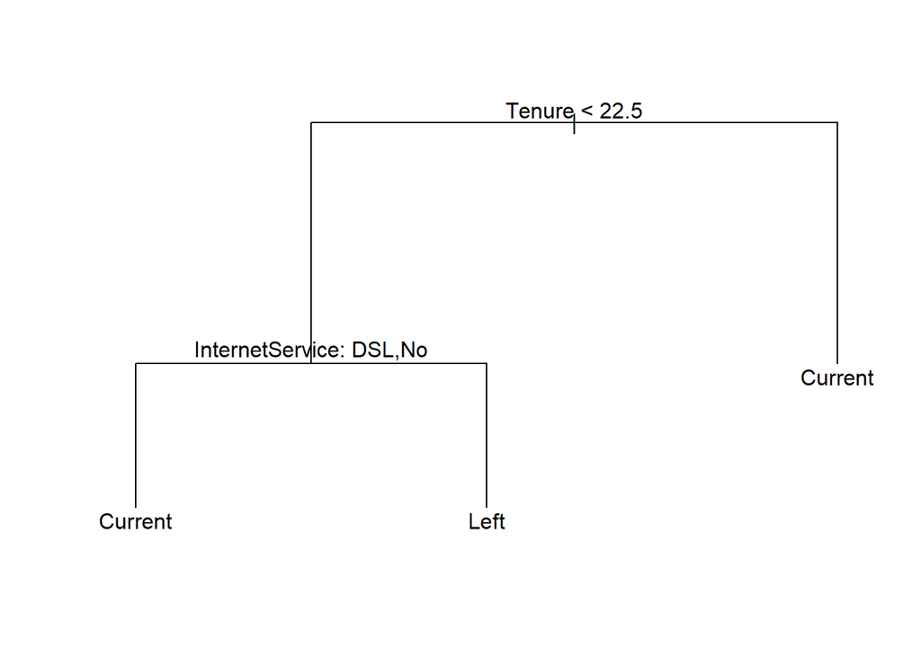

```
 Factor w/ 2 levels "Current","Left": 2 2 1 1 1 2 1 1 1 1 ...
```

```
              Status.test
tree.pred.test Current Left
       Current     932  211
       Left         88  169
```

```
[1] 78.64286
```

```
Classification tree:
tree(formula = Status ~ Gender + SeniorCitizen + Partner + Dependents +
    Contract + Tenure + PhoneService + MultipleLines2 + InternetService +
    OnlineSecurity2 + OnlineBackup2 + PaperlessBilling + PaymentMethod +
    MonthlyCharges + TotalCharges, data = customer.train)
Variables actually used in tree construction:
[1] "Contract"        "InternetService" "Tenure"
Number of terminal nodes:  6
Residual mean deviance:  0.8792 = 4917 / 5593
Misclassification error rate: 0.2095 = 1173 / 5599
```

```r
plot(tree.Customer.train)
# The argument *pretty = 0* instructs R to include the category names for any qualitative predictors, rather than simply displaying a letter for each category
text(tree.Customer.train, pretty = 0)
```

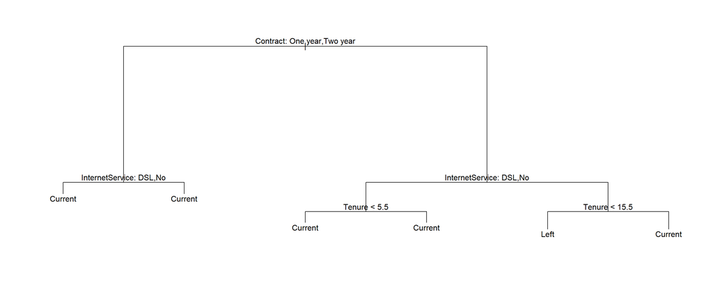

```
node), split, n, deviance, yval, (yprob)
      * denotes terminal node

 1) root 5599 6459.0 Current ( 0.73638 0.26362 )
   2) Contract: One year,Two year 2508 1222.0 Current ( 0.93381 0.06619 )
     4) InternetService: DSL,No 1741  522.1 Current ( 0.96554 0.03446 ) *
     5) InternetService: Fiber optic 767  616.2 Current ( 0.86180 0.13820 ) *
   3) Contract: Month-to-month 3091 4213.0 Current ( 0.57619 0.42381 )
     6) InternetService: DSL,No 1394 1654.0 Current ( 0.71951 0.28049 )
      12) Tenure < 5.5 596  805.8 Current ( 0.59228 0.40772 ) *
      13) Tenure > 5.5 798  765.4 Current ( 0.81454 0.18546 ) *
     7) InternetService: Fiber optic 1697 2341.0 Left ( 0.45846 0.54154 )
      14) Tenure < 15.5 821 1024.0 Left ( 0.31547 0.68453 ) *
      15) Tenure > 15.5 876 1184.0 Current ( 0.59247 0.40753 ) *
```

```
List of 4
 $ size  : int [1:3] 6 4 1
 $ dev   : num [1:3] 1189 1189 1476
 $ k     : num [1:3] -Inf 0 101
 $ method: chr "misclass"
 - attr(*, "class")= chr [1:2] "prune" "tree.sequence"
```

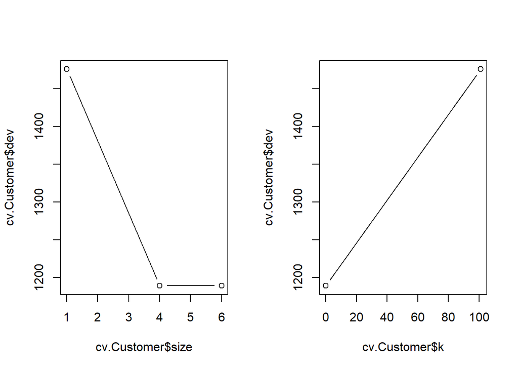

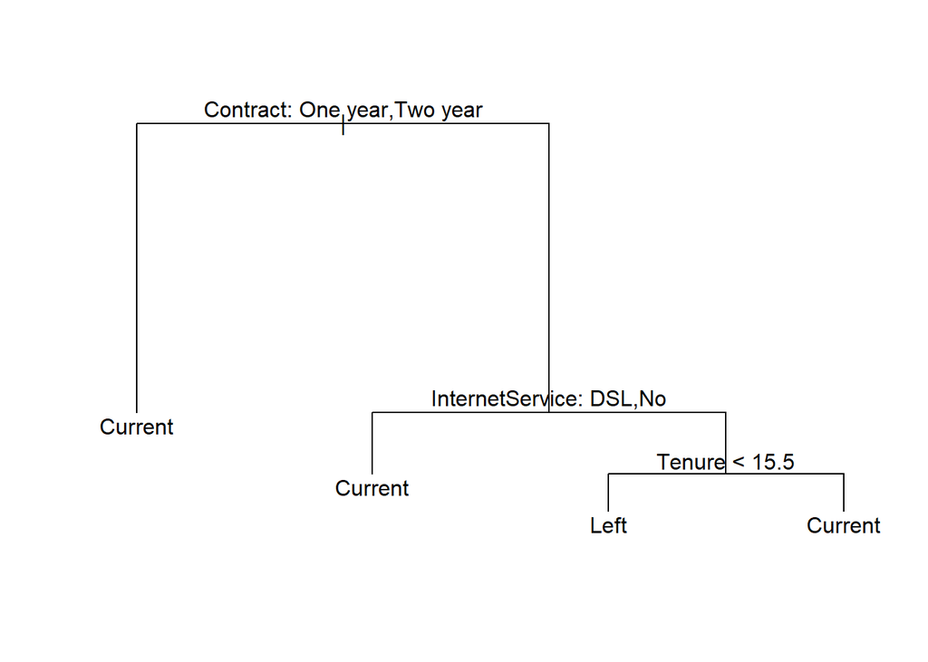

```
 Factor w/ 2 levels "Current","Left": 2 2 1 1 1 1 1 1 1 1 ...
```

```
              Status.test
tree.pred.test Current Left
       Current     960  230
       Left         60  150
```

```
[1] 79.28571
```

```r
plot(tree.Customer.train)
# The argument *pretty = 0* instructs R to include the category names for any qualitative predictors, rather than simply displaying a letter for each category
text(tree.Customer.train, pretty = 0)
```

[output not shown]

## 7. Comparison across Methods

- Compare across methods (skip the model built with decision trees) used above and report your best method based on ROC plots.
- Which model does the best in terms of the prediction accuracy on the test set? Include the decision tree model here.
- As a person in charge of making business decisions, what else are you learning from the results you are seeing from all these methods?

### Best Method based on ROC plot

The best model based on the maximum AUC value of .841. It was a logistic model without the variables Gender, Senior Citizen, Partner, Dependents, Phone Service, Online Security, Online Backup, Device Protection and Tech Support.

### Best Model based on Prediction Accuracy

The best model based on prediction accuracy had an a prediction accuracy value of 79.8% and a threshold of 0.55. It was also the logistic model without the variables Gender, Senior Citizen, Partner, Dependents, Phone Service, Online Security, Online Backup, Device Protection and Tech Support.

### General Takeaways

Based on running different models I found variables that are more and less effective in determining whether the status of the customer. Variables such as gender, dependent and partner are among the least effective variables. While running different models, I found dropping these variables in models had no effect on the maximum AUC values or the model improved without these variables. On the contrary, variables such as tenure, contract, internet service and total charges are among the most effective variables in determining the status of the customer. Including these variables in models produced high AUC values. The variables tenure,contract and internet services were the most significant variables in the decision tree.

## 8. Business Analysis and Recommendations

Pretend that the training dataset reflects the past and that the test data set captures the customers we are concerned about currently. Use your logistic regression model with your best threshold (identified in part 2) to answer the following questions: * In terms of relative importance how would you rate the predictors in your model. As a business manager, which factors would you focus on (for example you could invest in offering some incentives or promotions) to decrease the chances of customers leaving?

- Collect all the customers from the test dataset that your model says are going to leave. What is the predicted loss in revenue per month if all these customers leave? This reflects the loss if no action is taken
- Propose an incentive scheme to your manager that can help reduce the loss in revenue by retaining some (or all) customers. Provide justification by evaluating costs and benefits of your incentive scheme. Costs will be the dollar amount in incentives given (for example). Benefits will be the revenues from these customers if they stay with your company. Compute the net benefits from your incentive scheme. Make a case in your report to your upper management for implementing your scheme.

### Logistic Model with Best Threshold

```
Call:  glm(formula = Status ~ Tenure + MultipleLines2 + InternetService +
    StreamingTV2 + StreamingMovies2 + Contract + PaperlessBilling +
    PaymentMethod + MonthlyCharges + TotalCharges, family = binomial,
    data = customer.train)

Coefficients:
                         (Intercept)                                Tenure
                           1.2509902                            -0.0565747
                   MultipleLines2Yes            InternetServiceFiber optic
                           0.4792611                             2.0216969
                   InternetServiceNo                       StreamingTV2Yes
                          -1.7828231                             0.6431040
                 StreamingMovies2Yes                      ContractOne year
                           0.6423085                            -0.6595510
                    ContractTwo year                   PaperlessBillingYes
                          -1.4896765                             0.3948027
PaymentMethodCredit card (automatic)         PaymentMethodElectronic check
                          -0.0928823                             0.3824917
           PaymentMethodMailed check                        MonthlyCharges
                          -0.0198672                            -0.0441700
                        TotalCharges
                           0.0002831

Degrees of Freedom: 5598 Total (i.e. Null);  5584 Residual
Null Deviance:      6459
Residual Deviance: 4629     AIC: 4659
```

```
         1          2          3          4          5          6          7          8          9         10
0.46110806 0.58216138 0.10152824 0.08925463 0.34602244 0.57508315 0.23307063 0.07286211 0.30641827 0.08807231
```

```
        1         2         3         4         5         6         7         8         9        10
"Current"    "Left" "Current" "Current" "Current"    "Left" "Current" "Current" "Current" "Current"
```

```
Prediction_Classes Current Left
           Current     938  200
           Left         82  180
```

```
[1] 79.85714
```

### Variables to focus on

I think the top variables to focus on are tenure and contract. The goal of a company is to always grow and gain customers,but also keep their existing customers. I have explained below a proposed incentive to increase the customer tenure. Additionally, an incentive should also be implemented for contracts to keep customers at the company.

### Loss of Revenue if Customers Leave

```
# A tibble: 1 × 2
  Status total_monthly_charges
  <fct>                  <dbl>
1 Left                  28392.
```

### Sample Model with Incentive

```
# A tibble: 5,599 × 31
# Groups:   PhoneService, MultipleLines, InternetService, OnlineSecurity, OnlineBackup, DeviceProtection,
#   TechSupport, StreamingTV, StreamingMovies [320]
   Gender SeniorCitizen Partner Depen…¹ Tenure Phone…² Multi…³ Inter…⁴ Onlin…⁵ Onlin…⁶ Devic…⁷ TechS…⁸ Strea…⁹
   <fct>  <fct>         <fct>   <fct>    <int> <fct>   <fct>   <fct>   <fct>   <fct>   <fct>   <fct>   <fct>
 1 Female 0             Yes     Yes         48 Yes     Yes     Fiber … No      No      No      No      No
 2 Male   0             No      Yes         35 Yes     No      Fiber … No      No      Yes     No      Yes
 3 Male   0             Yes     Yes         52 Yes     Yes     No      No int… No int… No int… No int… No int…
 4 Male   1             Yes     No           1 Yes     Yes     Fiber … No      No      No      No      No
 5 Male   0             No      Yes         17 Yes     No      DSL     No      Yes     Yes     Yes     Yes
 6 Male   0             Yes     Yes          4 Yes     Yes     No      No int… No int… No int… No int… No int…
 7 Male   0             No      No           1 No      No pho… DSL     No      No      No      No      No
 8 Female 0             No      No           7 Yes     No      Fiber … No      No      No      No      Yes
 9 Female 0             Yes     No          14 Yes     No      No      No int… No int… No int… No int… No int…
10 Male   0             No      No           1 Yes     No      DSL     No      No      No      No      No
# … with 5,589 more rows, 18 more variables: StreamingMovies <fct>, Contract <fct>, PaperlessBilling <fct>,
#   PaymentMethod <fct>, MonthlyCharges <dbl>, TotalCharges <dbl>, Status <fct>, MultipleLines2 <chr>,
#   OnlineSecurity2 <chr>, OnlineBackup2 <chr>, DeviceProtection2 <chr>, TechSupport2 <chr>,
#   StreamingTV2 <chr>, StreamingMovies2 <chr>, Tenure_binned <fct>, mcharges_binned <fct>,
#   tcharges_binned <fct>, red_monthlycharges <dbl>, and abbreviated variable names ¹Dependents,
#   ²PhoneService, ³MultipleLines, ⁴InternetService, ⁵OnlineSecurity, ⁶OnlineBackup, ⁷DeviceProtection,
#   ⁸TechSupport, ⁹StreamingTV
```

```
         1          2          3          4          5          6          7          8          9         10
0.34296029 0.46272490 0.08662011 0.05659357 0.21795937 0.50561050 0.13246081 0.05265487 0.35900923 0.05895165
```

```
        1         2         3         4         5         6         7         8         9        10
"Current" "Current" "Current" "Current" "Current" "Current" "Current" "Current" "Current" "Current"
```

```
Prediction_Classes Current Left
           Current     976  250
           Left         44  130
```

```
[1] 79
```

### Incentive Model

My idea for an incentive model is to give discounts for customers based on the tenure as a customer. I noticed while looking at the initial distribution after 10 months a significant drop off in customers. Furthermore, my idea is to give $5 off monthly charges for customers who have been with the company for 10 months and longer. I created a sample model with the incentive implemented in the model. The prediction accuracy is on par with the best model. The costs of this change will be the loss in awarding the discounts to customers who have been with the customer for 10 months and longer. The benefits will be keeping existing customers for a longer period of time. In the future, a cost benefit analysis should be performed to analyze the logistics of this idea.